### 6. Identify the most important predictors.

```r
remove(list = ls())
CSRdata <- read.csv("CSRScore.csv")
df <- CSRdata
df <- df[complete.cases(df), ]


CSRdata <- df[complete.cases(CSRdata), ]
df <- CSRdata[, -1] #Dropping "CSR"
df$y <- ifelse(CSRdata$CSR < 33.09217, 1, 0) #groups outcome variable CSR into “poor” and “not poor” categories.
table(df$y)
```

```
##
##   0   1
## 571 196
```

```r
#Now, I will handle imbalanced data problem by using SMOTE.
library(DMwR)
df$y <- as.factor(df$y)
df <- SMOTE(y ~., df, perc.over =100, perc.under=200)
table(df$y)
```

```
##
##   0   1
## 381 392
```

```r
library(gplots)
library(PASWR)
library(ROCR)
library(rpart)
library(randomForest)
library(gbm)


df <- df[complete.cases(df), ]
df$d <- df$y
df$y <- as.integer(df$y)
df$y[df$y==1] <- 0
df$y[df$y==2] <- 1


n <- 20
B <- 1000
AUC3 <- c()

for (i in 1:n) {
  ind <- sample(nrow(df), nrow(df), replace = TRUE)
  train <- df[ind, ]
  test <- df[-ind, ]

  p = ncol(train)-2 #deleting survived and d columns. I need only 5 features.


  model3 <- randomForest(d~., ntree = B, data = train[, -33]) # RF
  phat3 <- predict(model3, test[,-33], type = "prob")

  #AUC3
  pred_rocr3 <- prediction(phat3[,2], test$d)
  auc_ROCR3 <- performance(pred_rocr3, measure = "auc")
  AUC3[i] <- auc_ROCR3@y.values[[1]]
}


mean(AUC3)
```

```
## [1] 0.8971718
```

```r
sqrt(var(AUC3) * n / (n - 1))
```

```
## [1] 0.01852239
```

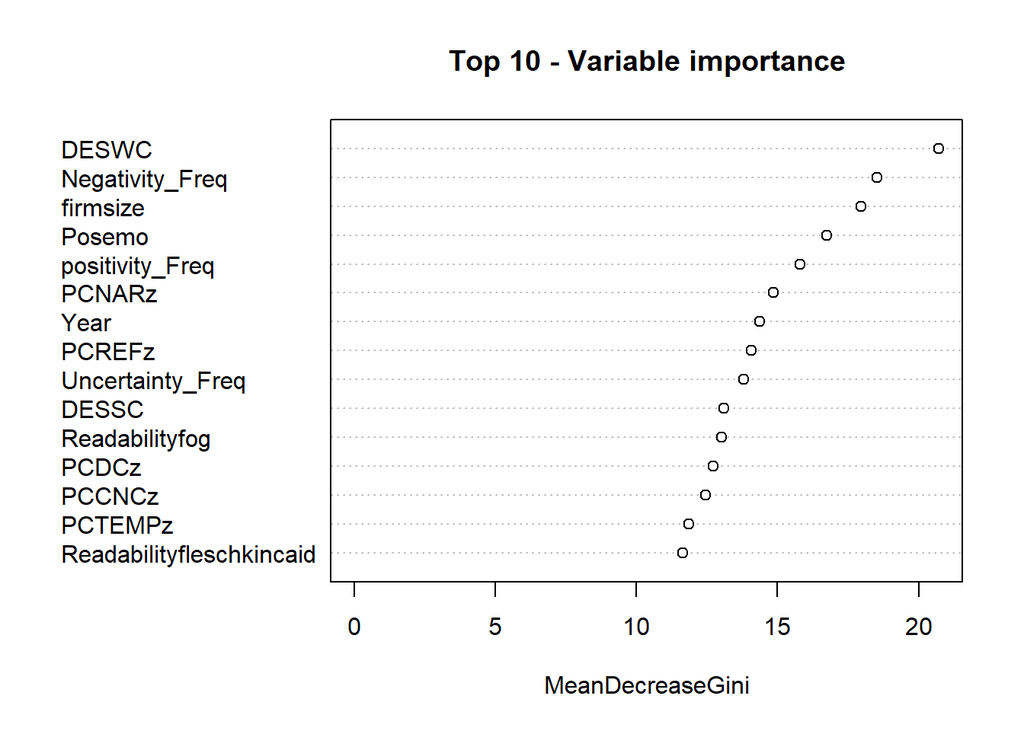

```r
varImpPlot(model3, sort = T, n.var = 15, main = "Top 10 - Variable importance")
```

```r
importance(model3)
```

```
##                          MeanDecreaseGini
## DESPC                           10.696909
## DESSC                           13.087196
## DESWC                           20.720219
## DESPL                            9.649027
## DESPLd                          10.241021
## DESSL                           10.658558
## DESSLd                          10.142686
## DESWLsy                          8.266866
## DESWLsyd                        10.141917
## DESWLlt                          9.834516
## DESWLltd                         8.475707
## Year                            14.381531
## PCNARz                          14.860386
## PCSYNz                          11.293062
## PCCNCz                          12.437399
## PCREFz                          14.080492
## PCDCz                           12.713448
## PCVERBz                         10.290863
## PCCONNz                         10.520742
## PCTEMPz                         11.858931
## Readabilityfleschkincaid        11.643654
## Readabilityfog                  13.011190
## industry3                        6.638193
## firmsize                        17.970727
## RDFRE                            8.655189
## RDFKGL                           8.898745
## Posemo                          16.742687
## Negemo                           8.283867
## Negativity_Freq                 18.532867
## positivity_Freq                 15.789530
## ForwardLooking_Freq             11.457643
## Uncertainty_Freq                13.799835
```

```r
remove(list = ls())
CSRdata <- read.csv("CSRScore.csv")
df <- CSRdata
df <- df[complete.cases(df), ]


CSRdata <- df[complete.cases(CSRdata), ]
df <- CSRdata[, -1] #Dropping "CSR"
df$y <- ifelse(CSRdata$CSR > 50.82640, 1, 0) #groups outcome variable CSR into “excellent” and “not excellent” categories.
table(df$y)
```

```
##
##   0   1
## 584 183
```

```r
library(DMwR)
df$y <- as.factor(df$y)# SMOTE requires the outcome variable to be a factor variable
df <- SMOTE(y ~., df, perc.over =100, perc.under=200)
table(df$y)
```

```
##
##   0   1
## 349 366
```

```r
library(PASWR)
library(ROCR)
library(rpart)
library(randomForest)

df <- df[complete.cases(df), ]
# Default RF
model <-randomForest(y ~., data = df)
model
```

```
##
## Call:
##  randomForest(formula = y ~ ., data = df)
##                Type of random forest: classification
##                      Number of trees: 500
## No. of variables tried at each split: 5
##
##         OOB estimate of  error rate: 10.63%
## Confusion matrix:
##     0   1 class.error
## 0 307  42  0.12034384
## 1  34 332  0.09289617
```

```r
library(PASWR)
library(ROCR)
library(rpart)
library(randomForest)

df <- df[complete.cases(df), ]
AUC <- c()
maxnode=c(10, 50, 100, 250, 500, 750, 1000)

for (i in 1:length(maxnode)) {
model <-randomForest(y ~., maxnodes = maxnode[i], data = df)
phat <- model$votes[,2]
#AUC
pred_rocr1 <- prediction(phat, df$y)
auc_ROCR1 <- performance(pred_rocr1, measure = "auc")
AUC[i] <- auc_ROCR1@y.values[[1]]
print(c(maxnode[i],AUC[i]))
}
```

```
## [1] 10.0000000  0.8236452
## [1] 50.0000000  0.9370136
## [1] 100.0000000   0.9642499
## [1] 250.0000000   0.9611536
## [1] 500.000000   0.963651
```

```
## [1] 750.0000000   0.9656121
```

```
## [1] 1000.0000000    0.9634436
```

### 1. Classification problem (0 and 1), predicting the type of CEO letter to shareholders, whether CEO letter is from annual report Or CSR report.

CEOs write two letters to shareholders, one letter is included in a company annual report, the second one is included in CSR report. I extract the two letters from S&P 500 companies and based on the CEO letter lingustics features, I will predict whether CEO letter is from annual report Or CSR report. The idea is that I wanted to know if there is a differernce between CEOs wirting style in their letter to shareholder in annual report and thier wirting style in their letter to shareholder CSR report.

### A. **1 indicates CEO letter from a company annual reprot**

### B. **0 indicates CEO letter from a company CSR reprot**

### 2. Import the data

```r
remove(list = ls())
data <- read.csv("data.csv")
df <- data
str(df)
```

```
## 'data.frame':    2790 obs. of  22 variables:
##  $ DESPC   : int  23 41 23 27 31 16 15 20 29 26 ...
##  $ DESSC   : int  51 70 49 46 52 33 45 38 68 58 ...
##  $ DESWC   : int  1004 1252 792 598 844 671 785 740 1320 1241 ...
##  $ DESPL   : num  2.22 1.71 2.13 1.7 1.68 ...
##  $ DESPLd  : num  1.043 0.68 1.359 0.953 1.222 ...
##  $ DESSL   : num  19.9 18.3 16.7 13.4 16.5 ...
##  $ DESSLd  : num  9.15 7.36 7.01 6.37 8.04 ...
##  $ DESWLsy : num  1.71 1.74 1.74 1.76 1.68 ...
##  $ DESWLsyd: num  0.97 0.971 0.98 1.006 0.95 ...
##  $ DESWLlt : num  5.07 5.17 5.24 5.31 4.95 ...
##  $ DESWLltd: num  2.94 3.02 3.14 3.08 2.81 ...
##  $ PCNARz  : num  0.037 -0.295 -0.155 -0.199 -0.171 ...
##  $ PCSYNz  : num  -0.059 0.011 0.209 0.689 0.106 ...
##  $ PCCNCz  : num  0.001 -0.306 -0.329 -0.584 -0.367 ...
##  $ PCREFz  : num  -0.183 0.156 -0.314 -0.301 0.027 ...
##  $ PCDCz   : num  0.587 -0.038 -0.134 0.133 0.557 ...
##  $ PCVERBz : num  -1.21 -1.319 -1.649 -2.302 -0.882 ...
##  $ PCCONNz : num  -1.577 -1.565 -2.106 -0.946 -1.885 ...
##  $ PCTEMPz : num  -1.282 -0.847 0.104 -0.571 0.45 ...
##  $ RDFRE   : num  42.4 41.6 43.1 44.5 47.9 ...
##  $ RDFKGL  : num  12.2 11.9 11.3 10.3 10.6 ...
##  $ type    : int  1 1 1 1 1 1 1 1 1 1 ...
```

let’s check if we have imbalanced data problem

```r
df$type <- as.factor(df$type)
table(df$type)
```

```
##
##    0    1
##  805 1985
```

Now, I will handle imbalanced data problem by using SMOTE.

```r
library(DMwR)
df <- SMOTE(type ~., df, perc.over =100, perc.under=200)
table(df$type)
```

```
##
##    0    1
## 1610 1610
```

```r
library(gplots)
library(PASWR)
library(ROCR)
library(rpart)
library(randomForest)
library(gbm)


df <- df[complete.cases(df), ]
df$d <- df$type
df$type <- as.integer(df$type)
df$type[df$type==1] <- 0
df$type[df$type==2] <- 1


n <- 20
B <- 1000
AUC1 <- c()
AUC2 <- c()
AUC3 <- c()
AUC4 <- c()

for (i in 1:n) {
  ind <- sample(nrow(df), nrow(df), replace = TRUE)
  train <- df[ind, ]
  test <- df[-ind, ]

  p = ncol(train)-2 #deleting survived and d columns. I need only 5 features.

  model1 <- rpart(type~., data=train[,-23], method = "class")
  model2 <- randomForest(d~., ntree = B, mtry = p, data = train[, -22]) #Bagged (-33 to drop y)
  model3 <- randomForest(d~., ntree = B, data = train[, -22]) # RF
  model4 <- gbm(type~., data=train[,-23], n.trees = B, distribution = "bernoulli") # Boosting

  phat1 <- predict(model1, test[,-23], type = "prob")
  phat2 <- predict(model2, test[,-22], type = "prob")
  phat3 <- predict(model3, test[,-22], type = "prob")
  phat4 <- predict(model4, n.trees = B, test[,-23], type = "response")

  #AUC1
  pred_rocr1 <- prediction(phat1[,2], test$type)
  auc_ROCR1 <- performance(pred_rocr1, measure = "auc")
  AUC1[i] <- auc_ROCR1@y.values[[1]]

  #AUC2
  pred_rocr2 <- prediction(phat2[,2], test$d)
  auc_ROCR2 <- performance(pred_rocr2, measure = "auc")
  AUC2[i] <- auc_ROCR2@y.values[[1]]

  #AUC3
  pred_rocr3 <- prediction(phat3[,2], test$d)
  auc_ROCR3 <- performance(pred_rocr3, measure = "auc")
  AUC3[i] <- auc_ROCR3@y.values[[1]]

  #AUC4
  pred_rocr4 <- prediction(phat4, test$type)
  auc_ROCR4 <- performance(pred_rocr4, measure = "auc")
  AUC4[i] <- auc_ROCR4@y.values[[1]]
}

mean(AUC1)
```

```
## [1] 0.9079913
```

```r
mean(AUC2)
```

```
## [1] 0.9858063
```

```r
mean(AUC3)
```

```
## [1] 0.9894454
```

```r
mean(AUC4)
```

```
## [1] 0.9844803
```

```r
sqrt(var(AUC1) * n / (n - 1))
```

```
## [1] 0.01142526
```

```r
sqrt(var(AUC2) * n / (n - 1))
```

```
## [1] 0.002812882
```

```r
sqrt(var(AUC3) * n / (n - 1))
```

```
## [1] 0.00190331
```

```r
sqrt(var(AUC4) * n / (n - 1))
```

```
## [1] 0.002694396
```

### 4. **Parametric models**: LPM, Logistic, LPM/Logistic models with Ridge and LASSO.

### 4. 1. LPM and Logistic

```r
remove(list = ls())
data <- read.csv("data.csv")
df <- data

df$type <- as.factor(df$type)
table(df$type)
```

```
##
##    0    1
##  805 1985
```

```r
library(DMwR)
df <- SMOTE(type ~., df, perc.over =100, perc.under=200)
table(df$type)
```

```
##
##    0    1
## 1610 1610
```

```r
library(PASWR)
library(ROCR)
library(rpart)

df <- df[complete.cases(df), ]
df$type1 <- as.integer(df$type)##for LPM and type will be factor for logistic.
#df$type <- as.factor(df$type)


n <- 500
AUC1 <- c()
AUC2 <- c()

for (i in 1:n) {
ind <- sample(nrow(df), nrow(df), replace = TRUE)
train <- df[ind, ]
test <- df[-ind, ]

model1 <- lm(type1~., data=train[,-22])
#model2 <- glm(type~.,data = train[, -23], family = binomial, control=glm.control(maxit=1))


phat1 <- predict(model1, test[, -22], type = "response")
#phat2 <- predict(model2, test[, -23], type = "response")

#AUC1
pred_rocr1 <- prediction(phat1, test$type1)
auc_ROCR1 <- performance(pred_rocr1, measure = "auc")
AUC1[i] <- auc_ROCR1@y.values[[1]]

#AUC2
#pred_rocr2 <- prediction(phat2, test$type)
#auc_ROCR2 <- performance(pred_rocr2, measure = "auc")
#AUC2[i] <- auc_ROCR2@y.values[[1]]
}
mean(AUC1)
```

```
## [1] 0.9810136
```

```r
#mean(AUC2)
sqrt(var(AUC1) * n / (n - 1))
```

```
## [1] 0.003092748
```

```r
#sqrt(var(AUC2) * n / (n - 1))
```

Logistic gave me an error “glm.fit: algorithm did not converge”, and “Glm.fit: fitted probabilities numerically 0 or 1 occurred Warning message” when I run Logistic regression. I read online and found out that this problem occurs because there is perfect separation in logistic regression. This makes sense because I am trying to classify CEOs letter in a company annual reports and CSR report.Eventually, there will be a slight difference between CEOs writing style in both letters. it is recommended to use penalized regression. I use Ridge and Lasso and they work fine. Please find the the links below that explain the issue in more detail.

https://discuss.analyticsvidhya.com/t/glm-fit-fitted-probabilities-numerically-0-or-1-occurred-warning-message-when-i-run-logistic-regression/10390 https://stats.stackexchange.com/questions/11109/how-to-deal-with-perfect-separation-in-logistic-regression

### 4 .2. Parametric models: LPM and Logistic models with Ridge and LASSO.

## 4. 2. 1. First, let us find the optimal value of lambda.

```r
remove(list = ls())
data <- read.csv("data.csv")
df <- data

df$type <- as.factor(df$type)
table(df$type)
```

```
##
##    0    1
##  805 1985
```

```r
library(DMwR)
df <- SMOTE(type ~., df, perc.over =100, perc.under=200)
table(df$type)
```

```
##
##    0    1
## 1610 1610
```

```r
library(PASWR)
library(ROCR)
library(rpart)
library(glmnet)

df <- df[complete.cases(df), ]
df$type <- as.integer(df$type)
#df$y[df$y==1] <- 0
#df$y[df$y==2] <- 1


grid = 10^seq(10, -2, length = 100)
AUC3 <- c() #LPM/Ridge
MAUC3<- c() #LPM/Ridge

AUC4 <- c() #LPM/LASSO
MAUC4 <- c() #LPM/LASSO

AUC5 <- c() #Logistic/Ridge
MAUC5 <- c() #Logistic/Ridge

AUC6 <- c() #Logistic/LASSO
MAUC6 <- c() #Logistic/LASSO

for(i in 1:length(grid)){
for(j in 1:100){
set.seed(j)
ind <- sample(nrow(df), nrow(df), replace = TRUE)
#ind <- unique(ind)

train <- df[ind, ]
xtrain <- model.matrix(type~., train)[,-22]
ytrain <- df[ind, 22]

test <- df[-ind, ]
xtest <- model.matrix(type~., test)[,-22]
ytest <- df[-ind, 22]


model3 <- glmnet(xtrain, ytrain, alpha = 0, lambda = grid[i], thresh = 1e-12,)#LPM/Ridge
model4 <- glmnet(xtrain, ytrain, alpha = 1, lambda = grid[i], thresh = 1e-12,)#LPM/LASSO
model5 <- glmnet(xtrain, ytrain, alpha = 0, lambda = grid[i], thresh = 1e-12, family = "binomial") #Logistic/Ridge
model6 <- glmnet(xtrain, ytrain, alpha = 1, lambda = grid[i], thresh = 1e-12, family = "binomial") #Logistic/LASSO


phat3 <- predict(model3, s = grid[i], newx = xtest, type = "response")
phat4 <- predict(model4, s = grid[i], newx = xtest, type = "response")
phat5 <- predict(model5, s = grid[i], newx = xtest, type = "response")
phat6 <- predict(model6, s = grid[i], newx = xtest, type = "response")


#AUC3
pred3 <- prediction(phat3, ytest)
auc3 <- performance(pred3, measure = "auc")
AUC3[j] <- auc3@y.values[[1]]

#AUC4
pred4 <- prediction(phat4, ytest)
auc4 <- performance(pred4, measure = "auc")
AUC4[j] <- auc4@y.values[[1]]

#AUC5
pred5 <- prediction(phat5, ytest)
auc5 <- performance(pred5, measure = "auc")
AUC5[j] <- auc5@y.values[[1]]

#AUC6
pred6 <- prediction(phat6, ytest)
auc6 <- performance(pred6, measure = "auc")
AUC6[j] <- auc6@y.values[[1]]
}

MAUC3[i] <- mean(AUC3)
MAUC4[i] <- mean(AUC4)
MAUC5[i] <- mean(AUC5)
MAUC6[i] <- mean(AUC6)
}

max(MAUC3)
```

```
## [1] 0.9807104
```

```r
max(MAUC4)
```

```
## [1] 0.9799436
```

```r
max(MAUC5)
```

```
## [1] 0.9826483
```

```r
max(MAUC6)
```

```
## [1] 0.9815262
```

```r
grid[which.max(MAUC3)]
```

```
## [1] 0.0231013
```

```r
grid[which.max(MAUC4)]
```

```
## [1] 0.01
```

```r
grid[which.max(MAUC5)]
```

```
## [1] 0.01
```

```r
grid[which.max(MAUC6)]
```

```
## [1] 0.01
```

```r
remove(list = ls())
data <- read.csv("data.csv")
df <- data

df$type <- as.factor(df$type)
table(df$type)
```

```
##
##    0    1
##  805 1985
```

```r
library(DMwR)
df <- SMOTE(type ~., df, perc.over =100, perc.under=200)
table(df$type)
```

```
##
##    0    1
## 1610 1610
```

```r
library(PASWR)
library(ROCR)
library(rpart)
library(glmnet)

df <- df[complete.cases(df), ]
df$type <- as.integer(df$type)

AUC3 <- c() #LPM/Ridge
MAUC3<- c() #LPM/Ridge

AUC4 <- c() #LPM/LASSO
MAUC4 <- c() #LPM/LASSO

AUC5 <- c() #Logistic/Ridge
MAUC5 <- c() #Logistic/Ridge

AUC6 <- c() #Logistic/LASSO
MAUC6 <- c() #Logistic/LASSO


for(i in 1:500){
ind <- sample(nrow(df), nrow(df), replace = TRUE)
ind <- unique(ind)
train <- df[ind, ]
xtrain <- model.matrix(type~., train)[,-22]
ytrain <- df[ind, 22]
test <- df[-ind, ]
xtest <- model.matrix(type~., test)[,-22]
ytest <- df[-ind, 22]


model3 <- glmnet(xtrain, ytrain, alpha = 0, lambda = 0.03053856, thresh = 1e-12,)#LPM/Ridge
model4 <- glmnet(xtrain, ytrain, alpha = 1, lambda = 0.01, thresh = 1e-12,)#LPM/LASSO
model5 <- glmnet(xtrain, ytrain, alpha = 0, lambda = 0.01, thresh = 1e-12, family = "binomial") #Logistic/Ridge
model6 <- glmnet(xtrain, ytrain, alpha = 1, lambda = 0.01, thresh = 1e-12, family = "binomial") #Logistic/LASSO


phat3 <- predict(model3, s = 0.3764936, newx = xtest, type = "response")
phat4 <- predict(model4, s = 0.01321941, newx = xtest, type = "response")
phat5 <- predict(model5, s = 0.1629751, newx = xtest, type = "response")
phat6 <- predict(model6, s = 0.01321941, newx = xtest, type = "response")


#AUC3
pred3 <- prediction(phat3, ytest)
auc3 <- performance(pred3, measure = "auc")
AUC3[i] <- auc3@y.values[[1]]

#AUC4
pred4 <- prediction(phat4, ytest)
auc4 <- performance(pred4, measure = "auc")
AUC4[i] <- auc4@y.values[[1]]

#AUC5
pred5 <- prediction(phat5, ytest)
auc5 <- performance(pred5, measure = "auc")
AUC5[i] <- auc5@y.values[[1]]

#AUC6
pred6 <- prediction(phat6, ytest)
auc6 <- performance(pred6, measure = "auc")
AUC6[i] <- auc6@y.values[[1]]
}



mean(AUC3)
```

```
## [1] 0.9818366
```

```r
mean(AUC4)
```

```
## [1] 0.9808029
```

```r
mean(AUC5)
```

```
## [1] 0.9841408
```

```r
mean(AUC6)
```

```
## [1] 0.9829467
```

```r
sqrt(var(AUC3)*500/499)
```

```
## [1] 0.002573442
```

```r
sqrt(var(AUC4)*500/499)
```

```
## [1] 0.002586575
```

```r
sqrt(var(AUC5)*500/499)
```

```
## [1] 0.002282271
```

```r
sqrt(var(AUC6)*500/499)
```

```
## [1] 0.002425882
```